# COMPSCIX 415.2 Homework 5/Midterm

Weiren Wang

March 5, 2018

Github repository: https://github.com/bw62109/compscix-415-2-assignments

# Table of Contents

RStudio and R Markdown  
The Tidyverse packages  
R Basics  
Data import/export  
Visualization  
Data munging and wrangling  
EDA  
Git and Github

## The tidyverse packages

### 1.

Plotting - ggplot2  
Data munging/wrangling - dplyr  
Reshaping(speading and gathering)data - tidyr  
Importing/exporting data - readr

### 2.

Plotting - ggplot2 - geom_point() and facet_grid()  
Data munging - dplyr - filter() and arrange()  
Reshaping data - tidyr - gather() and spread()  
Importing/exporting data - readr - write_csv() and write_delim()

## R Basics

### 1.

delete “!”.

### 2.

Change the “c” from upper case to lower case correct code is my_string <- c(‘has’, ‘an’, ‘error’, ‘in’, ‘it’)

### 3.

The vector in the result is not composed of actual values/numbers, it is composed of strings. If we want the actual values in the vector, we need to delete the quotation mark ’’ around 3 and 4 which gives my_vector <- c(1, 2, 3, 4, 5)

## Data import/export

### 1.

```r
library(tidyverse)
rail_trail <- read_delim('rail_trail.txt', delim = '|')
glimpse(rail_trail)
```

```
## Observations: 90
## Variables: 10
## $ hightemp   <int> 83, 73, 74, 95, 44, 69, 66, 66, 80, 79, 78, 65, 41,...
## $ lowtemp    <int> 50, 49, 52, 61, 52, 54, 39, 38, 55, 45, 55, 48, 49,...
## $ avgtemp    <dbl> 66.5, 61.0, 63.0, 78.0, 48.0, 61.5, 52.5, 52.0, 67....
## $ spring     <int> 0, 0, 1, 0, 1, 1, 1, 1, 0, 0, 0, 1, 1, 0, 0, 1, 0, ...
## $ summer     <int> 1, 1, 0, 1, 0, 0, 0, 0, 1, 1, 1, 0, 0, 0, 0, 0, 1, ...
## $ fall       <int> 0, 0, 0, 0, 0, 0, 0, 0, 0, 0, 0, 0, 0, 1, 1, 0, 0, ...
## $ cloudcover <dbl> 7.6, 6.3, 7.5, 2.6, 10.0, 6.6, 2.4, 0.0, 3.8, 4.1, ...
## $ precip     <dbl> 0.00, 0.29, 0.32, 0.00, 0.14, 0.02, 0.00, 0.00, 0.0...
## $ volume     <int> 501, 419, 397, 385, 200, 375, 417, 629, 533, 547, 4...
## $ weekday    <int> 1, 1, 1, 0, 1, 1, 1, 0, 0, 1, 1, 1, 1, 1, 1, 1, 0, ...
```

### 2.

```r
saveRDS(rail_trail, file = 'rail_trail.rds')
rail_trail_rds <- readRDS('rail_trail.rds')
glimpse(rail_trail_rds)
```

```
## Observations: 90
## Variables: 10
## $ hightemp   <int> 83, 73, 74, 95, 44, 69, 66, 66, 80, 79, 78, 65, 41,...
## $ lowtemp    <int> 50, 49, 52, 61, 52, 54, 39, 38, 55, 45, 55, 48, 49,...
## $ avgtemp    <dbl> 66.5, 61.0, 63.0, 78.0, 48.0, 61.5, 52.5, 52.0, 67....
## $ spring     <int> 0, 0, 1, 0, 1, 1, 1, 1, 0, 0, 0, 1, 1, 0, 0, 1, 0, ...
## $ summer     <int> 1, 1, 0, 1, 0, 0, 0, 0, 1, 1, 1, 0, 0, 0, 0, 0, 1, ...
## $ fall       <int> 0, 0, 0, 0, 0, 0, 0, 0, 0, 0, 0, 0, 0, 1, 1, 0, 0, ...
## $ cloudcover <dbl> 7.6, 6.3, 7.5, 2.6, 10.0, 6.6, 2.4, 0.0, 3.8, 4.1, ...
## $ precip     <dbl> 0.00, 0.29, 0.32, 0.00, 0.14, 0.02, 0.00, 0.00, 0.0...
## $ volume     <int> 501, 419, 397, 385, 200, 375, 417, 629, 533, 547, 4...
## $ weekday    <int> 1, 1, 1, 0, 1, 1, 1, 0, 0, 1, 1, 1, 1, 1, 1, 1, 0, ...
```

## Visualization

### 1.

First, there are some important information missing, like when and where the survey has been made, as well as the number of people participated in this survey.  
Second, age and sex are different categories and interpretations of the data. They should be separated more clearly.  
Third, the sum of the percentages for each group doesn’t equal to 100. There might be some people in that group are not willing to answer the question or not sure about it.

### 2.

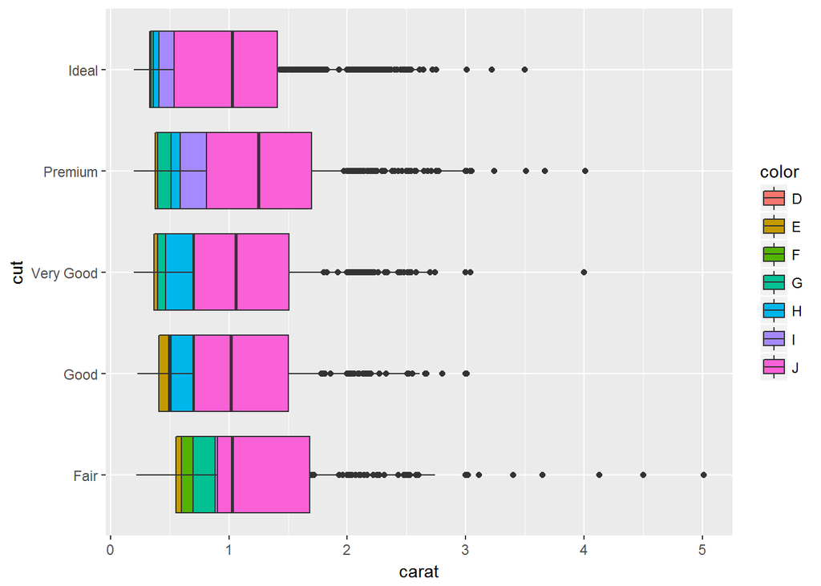

```r
library(ggplot2)
ggplot(data = diamonds, mapping = aes(x = cut, fill = color, y = carat))+
  geom_boxplot(position = "identity")+
  coord_flip()
```

### 3.

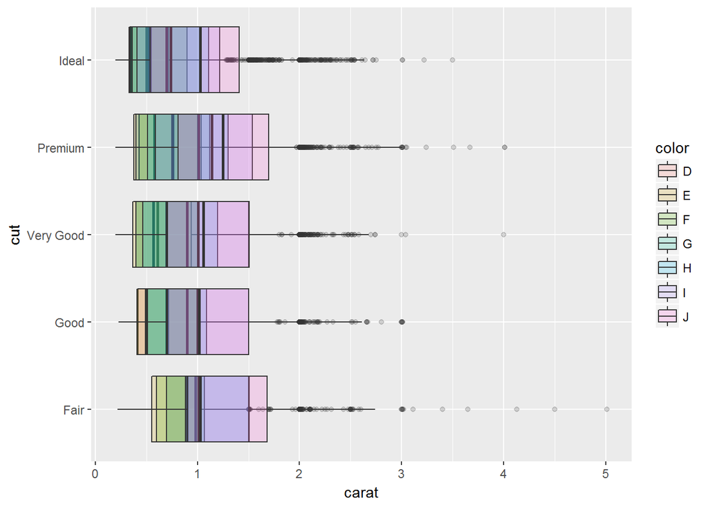

```r
ggplot(data = diamonds, mapping = aes(x = cut, fill = color, y = carat))+
geom_boxplot(alpha = 1/5, position = "identity")+
coord_flip()
```

## Data munging and wrangling

### 1.

No, this data is not tidy.

```r
library(tidyverse)
spread(table2, key = type, value = count)
```

```
## # A tibble: 6 x 4
##   country      year  cases population
##   <chr>       <int>  <int>      <int>
## 1 Afghanistan  1999    745   19987071
## 2 Afghanistan  2000   2666   20595360
## 3 Brazil       1999  37737  172006362
## 4 Brazil       2000  80488  174504898
## 5 China        1999 212258 1272915272
## 6 China        2000 213766 1280428583
```

### 2.

mutate(diamonds, price_per_carat = price / carat)

### 3.

Yes, the results make sense. smaller carat but more expensive diamonds normally have better cut. We need to be wary of the missing values in the dataset.

```r
diamonds %>%
  group_by(cut) %>%
  summarise(N = n(), selected_diamond_count = sum(price > 10000 & carat < 1.5), proportion_percetage = selected_diamond_count/N*100 )
```

```
## # A tibble: 5 x 4
##   cut           N selected_diamond_count proportion_percetage
##   <ord>     <int>                  <int>                <dbl>
## 1 Fair       1610                      4                0.248
## 2 Good       4906                     17                0.347
## 3 Very Good 12082                    155                1.28
## 4 Premium   13791                    173                1.25
## 5 Ideal     21551                    485                2.25
```

## EDA

### 1.

The data is from year 2000 to 2015.

### 2.

There are 46 cities represented.

### 3.

Houston in July 2015 had the highest number of sales of 8945.

### 4.

More number of listings leads to more number of sales, but at a diminishing return trend.

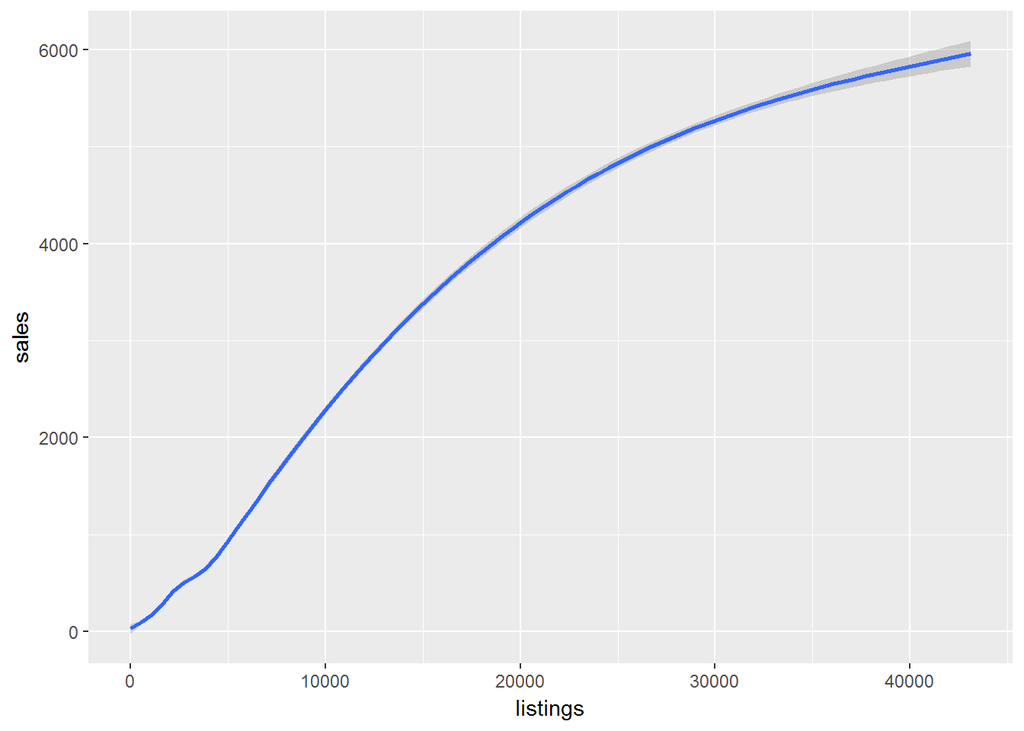

```r
ggplot(data = txhousing)+
  geom_smooth(mapping = aes(x = listings, y = sales))
```